# homework answers 3

Steve Simon

May 14, 2018

## 1. Recalculate the sample size in the lecture if the early dropout rate is 0.1 or 0.3 instead of 0.2.

First replicate the original calculations.

```r
pi <- 1/3
theta=log(2)
m <- (qnorm(0.975)+qnorm(0.80))^2/(theta^2*pi*(1-pi))
m
```

```
## [1] 73.51387
```

We have 73.5 total deaths. Round this up to 75, with 25 deaths in the treatment group and 50 in the control group.

Now calculate the survival of a patients for three years or more.

```r
m1 <- 25 # deaths in treatment group
m2 <- 50 # deaths in control group
lambda1 <- 0.4
hazard_ratio <- 2
t <- 3
survival_group1 <- round(exp(-lambda1*t), 2)
survival_group2 <- round(exp(-hazard_ratio*lambda1*t), 2)

dropout_rate <- 0.2

n1 <- ceiling(m1 / ((1-survival_group1)*(1-dropout_rate)))
n2 <- ceiling(m2 / ((1-survival_group2)*(1-dropout_rate)))
```

If the hazard rate is 0.4 in the treatment group, then the probability of survival to three years and beyond is

$e^{-\lambda t}$ = exp(-1.2) = 0.3.

The control group has a hazard rate that is twice as big, so the probability of survival for this group is

exp(-2.4) = 0.09.

The dropout rate is 0.2, so the number of patients in each group to achieve 25 and 50 deaths, respectively, is

$n_1$ = 25 / ((1- 0.3)(1-0.2)) = 45

$n_2$ = 50 / ((1- 0.09)(1-0.2)) = 69

```r
dropout_rate_a <- 0.1
n1_a <- round(m1 / ((1-survival_group1)*(1-dropout_rate_a)))
n2_a <- round(m2 / ((1-survival_group2)*(1-dropout_rate_a)))

dropout_rate_b <- 0.3
n1_b <- ceiling(m1 / ((1-survival_group1)*(1-dropout_rate_b)))
n2_b <- ceiling(m2 / ((1-survival_group2)*(1-dropout_rate_b)))
```

If you change the dropout rate to 0.1, then the sample sizes decrease to

$n_1$ = 25 / ((1- 0.3)(1-0.1)) = 40

$n_2$ = 50 / ((1- 0.09)(1-0.1)) = 61

If you change the dropout rate to 0.3, then the sample sizes increase to

$n_1$ = 25 / ((1- 0.3)(1-0.3)) = 52

$n_2$ = 50 / ((1- 0.09)(1-0.3)) = 79

Here’s a graph.

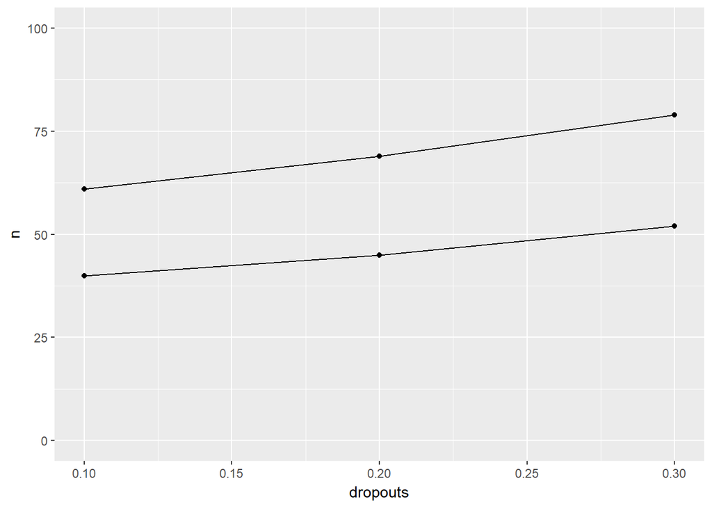

```r
library(ggplot2)
df <- data.frame(dropouts=rep((1:3)/10, 2), n=c(n1_a, n1, n1_b, n2_a, n2, n2_b), g=rep(1:2, each=3))
sensitivity_plot1 <- ggplot(df) +
  geom_point(aes(dropouts, n)) +
  geom_line(aes(group=g, x=dropouts, y=n)) +
  expand_limits(y=c(0, 100))
sensitivity_plot1
```

## 2. Recalculate the sample size if the average time of follow up is 2 years or 4 years instead of 3 years.

```r
t_c <- 2
survival_group1_c <- round(exp(-lambda1*t_c), 2)
survival_group2_c <- round(exp(-hazard_ratio*lambda1*t_c), 2)

n1_c <- ceiling(m1 / ((1-survival_group1_c)*(1-dropout_rate)))
n2_c <- ceiling(m2 / ((1-survival_group2_c)*(1-dropout_rate)))

t_d <- 4
survival_group1_d <- round(exp(-lambda1*t_d), 2)
survival_group2_d <- round(exp(-hazard_ratio*lambda1*t_d), 2)

n1_d <- ceiling(m1 / ((1-survival_group1_d)*(1-dropout_rate)))
n2_d <- ceiling(m2 / ((1-survival_group2_d)*(1-dropout_rate)))
```

Remember to switch the dropout rate back to 20% for this problem.

This takes a bit more work. The survival function for the exponential distribution is

$S(t)=e^{-\lambda t}$

For a two year follow up, $-\lambda t$ = -0.8 for the treatment group and -1.6 for the control group. So the survival probabilities increase from 0.3 and 0.09 to 0.45 and 0.2 respectively. The sample sizes needed to insure 25 and 50 deaths are

$n_1$ = 25 / ((1- 0.45)(1-0.2)) = 57

$n_2$ = 50 / ((1- 0.2)(1-0.2)) = 79

For a four year follow up, $-\lambda t$ = -1.6 for the treatment group and -3.2 for the control group. So the survival probabilities decrease from 0.3 and 0.09 to 0.2 and 0.04 respectively. The sample sizes needed to insure 25 and 50 deaths are

$n_1$ = 25 / ((1- 0.2)(1-0.2)) = 40

$n_2$ = 50 / ((1- 0.04)(1-0.2)) = 66

Here’s a graph

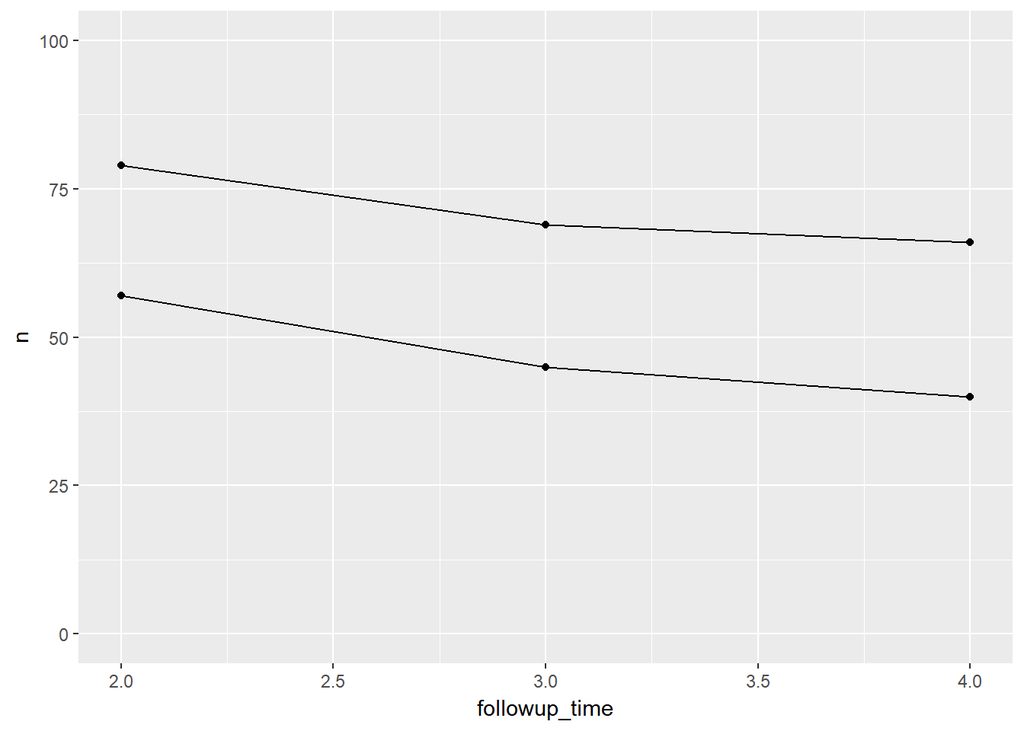

```r
library(ggplot2)
df <- data.frame(followup_time=rep(2:4, 2), n=c(n1_c, n1, n1_d, n2_c, n2, n2_d), g=rep(1:2, each=3))
sensitivity_plot2 <- ggplot(df) +
  geom_point(aes(followup_time, n)) +
  geom_line(aes(group=g, x=followup_time, y=n)) +
  expand_limits(y=c(0, 100))
sensitivity_plot2
```

## 3. Recalculate the sample size if the baseline hazard is 0.2 or 0.6 instead of 0.4.

```r
lambda1_e <- 0.2
survival_group1_e <- round(exp(-lambda1_e*t), 2)
survival_group2_e <- round(exp(-hazard_ratio*lambda1_e*t), 2)

n1_e <- ceiling(m1 / ((1-survival_group1_e)*(1-dropout_rate)))
n2_e <- ceiling(m2 / ((1-survival_group2_e)*(1-dropout_rate)))

lambda1_f <- 0.6
survival_group1_f <- round(exp(-lambda1_f*t), 2)
survival_group2_f <- round(exp(-hazard_ratio*lambda1_f*t), 2)

n1_f <- ceiling(m1 / ((1-survival_group1_f)*(1-dropout_rate)))
n2_f <- ceiling(m2 / ((1-survival_group2_f)*(1-dropout_rate)))
```

For a baseline hazard of 0.2 and 3 years of follow up, you can compute, $-\lambda t$ = -0.6 for the treatment group and -1.2 for the control group. So the survival probabilities increase from 0.3 and 0.09 to 0.55 and 0.3 respectively. The sample sizes needed to insure 25 and 50 deaths are

$n_1$ = 25 / ((1- 0.55)(1-0.2)) = 70

$n_2$ = 50 / ((1- 0.3)(1-0.2)) = 90

$n_1$ = 25 / ((1- 0.17)(1-0.2)) = 38

$n_2$ = 50 / ((1- 0.03)(1-0.2)) = 65

Here’s a graph

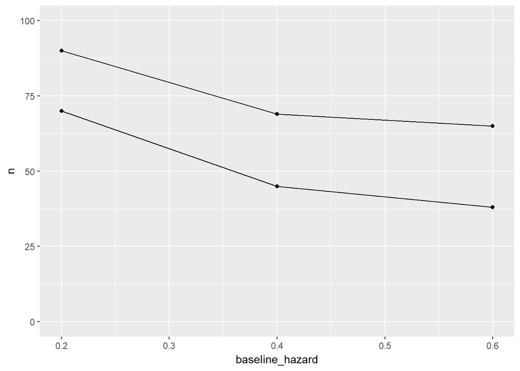

```r
library(ggplot2)
df <- data.frame(
  baseline_hazard=rep(c(lambda1_e, lambda1, lambda1_f), 2),
  n=c(n1_e, n1, n1_f, n2_e, n2, n2_f),
  g=rep(1:2, each=3))
sensitivity_plot3 <- ggplot(df) +
  geom_point(aes(baseline_hazard, n)) +
  geom_line(aes(baseline_hazard, n, group=g)) +
  expand_limits(y=c(0, 100))
sensitivity_plot3
```

## 4. Recalculate the sample size if the hazard ratio is 1.8 or 2.2 instead of 2.0.

A hazard ratio closer to 1.0 should force you to collect more deaths. Note that $\theta$ = log(1.8) = 0.588. Let’s keep $\pi$ at 0.33.

```r
hazard_ratio_g <- 1.8
pi <- 1/3
theta=log(hazard_ratio_g)
m_gx <- (qnorm(0.975)+qnorm(0.80))^2/(theta^2*pi*(1-pi))
m_g <- ceiling(m_gx/3)*3
m1_g <- m_g / 3
m2_g <- 2 * m1_g

# Changing the hazard ratio only changes the survival probability in the second group.
survival_group2_g <- round(exp(-hazard_ratio_g*lambda1*t), 2)

n1_g <- ceiling(m1_g / ((1-survival_group1)*(1-dropout_rate)))
n2_g <- ceiling(m2_g / ((1-survival_group2_g)*(1-dropout_rate)))

hazard_ratio_h <- 2.2
pi <- 1/3
theta=log(hazard_ratio_h)
m_hx <- (qnorm(0.975)+qnorm(0.80))^2/(theta^2*pi*(1-pi))
m_h <- ceiling(m_hx/3)*3
m1_h <- m_h / 3
m2_h <- 2 * m1_h

# Changing the hazard ratio only changes the survival probability in the second group.
survival_group2_h <- round(exp(-hazard_ratio_h*lambda1*t), 2)

n1_h <- ceiling(m1_h / ((1-survival_group1)*(1-dropout_rate)))
n2_h <- ceiling(m2_h / ((1-survival_group2_h)*(1-dropout_rate)))
```

A hazard ratio of 1.8 would require 102.2 total deaths. Round this up to 105, with 35 deaths in the first group and 70 deaths in the second group.

Adjusting for survival beyond 3 years and a 20% dropout rate, you get

$n_1 =$ 35 / ((1-0.2)(1-0.3)) = 63.

$n_2 =$ 70 / ((1-0.2)(1-0.12)) = 100.

Now consider an increase in the hazard ratio to 2.2. This would require 56.8 deaths. Round this up to 57, with 19 deaths in the first group and 38 deaths in the second group.

Adjusting for survival beyond 3 years and a 20% dropout rate, you get

$n_1 =$ 19 / ((1-0.2)(1-0.3)) = 34.

$n_2 =$ 38 / ((1-0.2)(1-0.07)) = 52.

Here’s a graph.

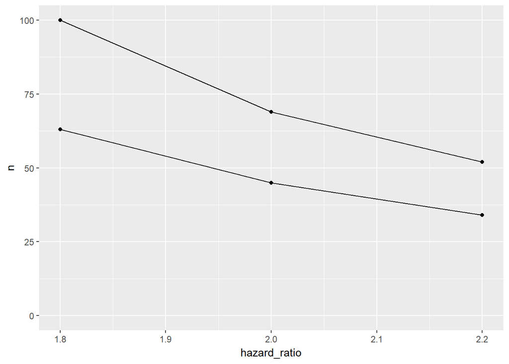

```r
library(ggplot2)
df <- data.frame(
  hazard_ratio=rep(c(hazard_ratio_g, hazard_ratio, hazard_ratio_h), 2),
  n=c(n1_g, n1, n1_h, n2_g, n2, n2_h),
  g=rep(1:2, each=3))
sensitivity_plot4 <- ggplot(df) +
  geom_point(aes(hazard_ratio, n)) +
  geom_line(aes(hazard_ratio, n, group=g)) +
  expand_limits(y=c(0, 100))
sensitivity_plot4
```

Now let’s look at all four sensitivity plots together.

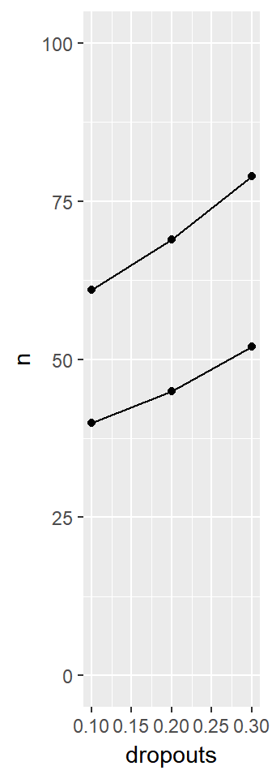

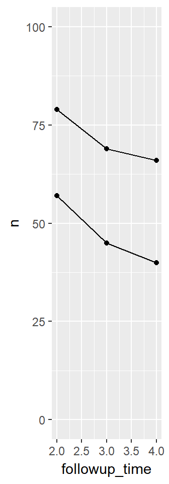

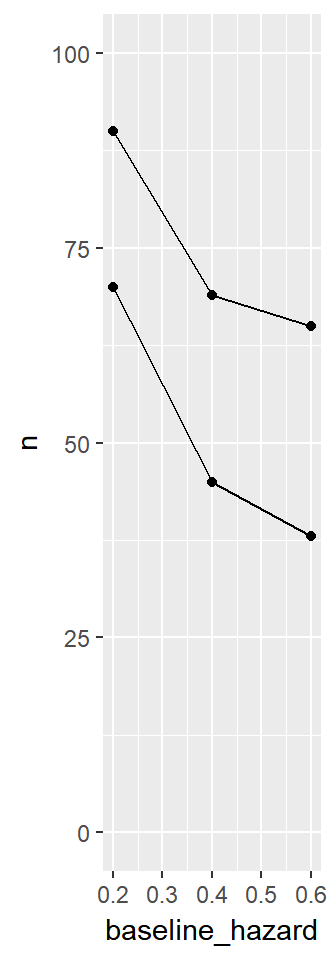

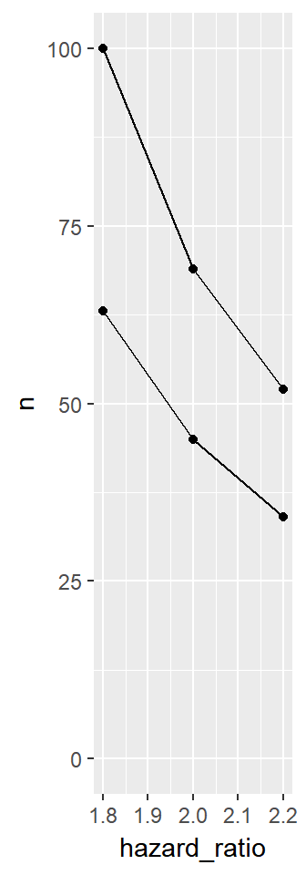

## 5. Do the changes in sample size fit your intuition?

They made sense to me. I hope they made sense to you also.

## 6. Put today’s date into a statistical package of your choice and convert it to a numeric value. Does the number seem surprising to you?

In Excel, May 14, 2018 translates to 43,234. Divide that by 365.25 to get 118.4 years. This seems to be consistent with a date of origin around 1900.

In R, May 14, 2018, translates to 17,665. Divide again by 365.25 to get 48.4 which matches a date of origin around 1970.

In SPSS, May 14, 2018 translates to 13,745,635,200. Divide first by 86,400 (=24 hours times 60 minutes times 60 seconds) and then by 365.25 to get 435.6.